# YumPy

**Group Members:**

- Randi Howell
- Kyrus Wankadiya
- Catherine Safrit
- Monica Sehgal

### Data Used

- Income: https://www.kaggle.com/muonneutrino/us-census-demographic-data/data
- Education: https://www.ers.usda.gov/data-products/county-level-data-sets/
- Yelp Fusion API: https://www.yelp.com/fusion

# From the top!

We decided to use the Yelp api, demographic census information, and education data to explore potential correlations. Below is an outline of our projec:

### Part 1: Initial Setup

Once the CSV files were read in, we modified them as needed to fit in out dataframe. To check the formatting, we used a print statement.

```python
import yelpapi
import json
import requests
from  pprint import  pprint
import pandas as pd
import numpy as np
import random
import matplotlib.pyplot as plt
import seaborn as sns

#reading in county data
counties=pd.read_csv("acs2015_county_data.csv")
counties["county_string"] = counties["County"] + " County, " + counties["State"]
listofcounties = counties["county_string"].tolist()
#reading in zipcodes
zipcodes=pd.read_csv("zip_codes_states.csv")
zipcodes["county_string"] = zipcodes["county"] + " County, " + zipcodes["state"]
listofzipcodes=zipcodes["county_string"].unique().tolist()
counties.to_csv("counties.csv")
zipcodes.to_csv("zcs.csv")
fullcountylist = list(set(listofcounties) & set(listofzipcodes))
counties.head(1)
```

|  | CensusId | State | County | TotalPop | Men | Women | Hispanic | White | Black | Native | ... | OtherTransp | WorkAtHome | MeanCommute | Employed | PrivateWork | PublicWork | SelfEmployed | FamilyWork | Unemployment | county_string |
| --- | --- | --- | --- | --- | --- | --- | --- | --- | --- | --- | --- | --- | --- | --- | --- | --- | --- | --- | --- | --- | --- |
| 0 | 1001 | Alabama | Autauga | 55221 | 26745 | 28476 | 2.6 | 75.8 | 18.5 | 0.4 | ... | 1.3 | 1.8 | 26.5 | 23986 | 73.6 | 20.9 | 5.5 | 0.0 | 7.6 | Autauga County, Alabama |

1 rows × 38 columns

### Part 1: County Setup

In the framework portion, we established regions of the US that we will use later, created a new dataframe that holds out counties, and created a list to hold all the randomly generated countries. This will be more important later.

```python
#creating regions
WC = ["Washington","Oregon","California","Nevada","Idaho"]
MW = ["Montana","Wyoming","North Dakota","South Dakota","Nebraska","Kansas","Minnesota","Iowa","Missouri",
      "Wisconsin","Illinois","Michigan","Indiana","Ohio","Kentucky"]
SW = ["Arizona","Utah","Colorado","New Mexico","Oklahoma","Texas"]
SE = ["Arkansas","Louisiana","Mississippi","Alabama","Tennessee","Virginia","West Virginia","North Carolina","South Carolina","Georgia","Florida"]
NE = ["District of Columbia","Pennsylvania","Maryland","Delaware","New Jersey","New York","Maine","New Hampshire","Vermont","Massachusetts","Rhode Island","Connecticut"]
counties["Region"]= np.where(counties["State"].isin(WC),'WC',
                    np.where(counties["State"].isin(MW),'MW',
                    np.where(counties["State"].isin(SW),'SW',
                    np.where(counties["State"].isin(SE),'SE',
                    np.where(counties["State"].isin(NE),'NE',
                             'other')))))
```

```python
#counties.groupby(["Region"]).sum()["TotalPop"]
cdf = pd.DataFrame(counties,columns=["county_string","Region"])
WClist = (cdf.groupby("Region").get_group("WC")["county_string"]).tolist()
MWlist = (cdf.groupby("Region").get_group("MW")["county_string"]).tolist()
SWlist = (cdf.groupby("Region").get_group("SW")["county_string"]).tolist()
SElist = (cdf.groupby("Region").get_group("SE")["county_string"]).tolist()
NElist = (cdf.groupby("Region").get_group("NE")["county_string"]).tolist()

sample_list = ["Mecklenburg County, North Carolina"]
sample_list.extend(random.sample(list(set(WClist) & set(fullcountylist)),10))
sample_list.extend(random.sample(list(set(MWlist) & set(fullcountylist)),10))
sample_list.extend(random.sample(list(set(SWlist) & set(fullcountylist)),10))
sample_list.extend(random.sample(list(set(SElist) & set(fullcountylist)),9))
sample_list.extend(random.sample(list(set(NElist) & set(fullcountylist)),10))
sample_list
```

```
['Mecklenburg County, North Carolina',
 'Shoshone County, Idaho',
 'Pend Oreille County, Washington',
 'Linn County, Oregon',
 'Morrow County, Oregon',
 'Kitsap County, Washington',
 'Jefferson County, Washington',
 'Wasco County, Oregon',
 'Clackamas County, Oregon',
 'Santa Cruz County, California',
 'San Benito County, California',
 'Rice County, Minnesota',
 'Boone County, Missouri',
 'Hamilton County, Kansas',
 'Moody County, South Dakota',
 'Barry County, Missouri',
 'Summit County, Ohio',
 'Gallia County, Ohio',
 'Montgomery County, Kansas',
 'Scott County, Indiana',
 'Graves County, Kentucky',
 'Osage County, Oklahoma',
 'Schleicher County, Texas',
 'Runnels County, Texas',
 'Henderson County, Texas',
 'Bee County, Texas',
 'Wood County, Texas',
 'Pueblo County, Colorado',
 'Hamilton County, Texas',
 'Texas County, Oklahoma',
 'Randall County, Texas',
 'Warren County, Tennessee',
 'Glascock County, Georgia',
 'Franklin County, Florida',
 'East Feliciana County, Louisiana',
 'Crockett County, Tennessee',
 'Geneva County, Alabama',
 'Yazoo County, Mississippi',
 'Buncombe County, North Carolina',
 'Citrus County, Florida',
 'Erie County, New York',
 'Columbia County, New York',
 'Sussex County, Delaware',
 'Westmoreland County, Pennsylvania',
 'Providence County, Rhode Island',
 'Essex County, New York',
 'Strafford County, New Hampshire',
 'Kent County, Delaware',
 'Crawford County, Pennsylvania',
 'Pike County, Pennsylvania']
```

### Part 1: Establishing the Main DataFrame

After reading in the county data and creating regions, we established our primary dataframe. We named the dataframe res_df. This dataframe will be used throughout the project.

```python
res_df = pd.DataFrame(columns=["name","zipcode","county_string","rating","review_count","category","price","region"])
res_df
```

|  | name | zipcode | county_string | rating | review_count | category | price | region |
| --- | --- | --- | --- | --- | --- | --- | --- | --- |

### Part 1: The Framework - Kyrus For Loop

Kyrus also included a try/ecxcept option as a way to check or verify the code was working and pulling in the data correctly.

```python
term = ["Italian","Mexican","Chinese","American (Traditional)","American (New)","Indian"]
r = 0
for c in sample_list:
    county_string = str(c)
    if 1==1:
        #we are allowed 5000 queries per 24 hours. if we run out, we can create another. till then, use this
        yelpkey="IXRN_1GI8f8J9Kj5O5GciqeyFSWR5RMh41_rADGy1KrtQ5ZABGGZEkWwot5mOka0NlzlNxXPmzYXLWk88oOV0N_YxD1MSW4kQRfJnFrwfHLtKrr2HcsjLo6uWBzAWnYx"
        if 1==1:

            for offset in range(0,49):

                response = requests.get(url="https://api.yelp.com/v3/businesses/search",
                       params= {"location": county_string, "limit":"20", "offset": offset*20},#"term": term},
                       headers={'Authorization': 'bearer %s' % yelpkey})
                responsejson = response.json()
                print(offset*20)
                if 1==1:
                    count=0
                    for x in range(0,len(responsejson["businesses"])):

                        try:
                            if((responsejson["businesses"][x]["review_count"] > 0)):
                                zc = int(responsejson["businesses"][x]["location"]["zip_code"])

                                try:

                                    if (zipcodes.loc[zipcodes["zip_code"]==zc]["county_string"].tolist()[0]== county_string):
                                        for y in range(0,len(responsejson["businesses"][x]["categories"])):
                                            if 1==1:
                                                print("\n",responsejson["businesses"][x]["name"],
                                                        responsejson["businesses"][x]["location"]["zip_code"],
                                                        zipcodes.loc[zipcodes["zip_code"]==zc]["county_string"].tolist()[0],
                                                        responsejson["businesses"][x]["rating"],
                                                        responsejson["businesses"][x]["review_count"],
                                                        responsejson["businesses"][x]["categories"][y]["title"])
                                                if str(responsejson["businesses"][x]["categories"][y]["title"]) in (term):
                                                    res_df.loc[r]=[responsejson["businesses"][x]["name"],
                                                        str(zc),
                                                        county_string,
                                                        responsejson["businesses"][x]["rating"],
                                                        responsejson["businesses"][x]["review_count"],
                                                        responsejson["businesses"][x]["categories"][y]["title"],
                                                        responsejson["businesses"][x]["price"],
                                                        "region"
                                                    ]

                                                    r += 1
                                                count += 1

                                            #except:
                                            #    print("")
                                            #    break
                                except:
                                    print("ERROR1")
                                #    break

                        except:
                            print("ERROR2")
                        #    break
                #except:
                #    print("ERROR3")
                #    break

                #print("End of list. Found", count, term, "restaurants in", county_string)
        #except:
        #    print("ERROR4: this one should never happen")
        #    break
```

[output not shown]

[output cut: 28679 more lines]

[output not shown]

### Part 1: Cleaning the Data

After waiting forever for the Kyrus for loop to finish, we needed to clean up the data. Early on, we noticed that res_df displayed \$, \$\$, and \$\$\$ in the price column, but would not show \$\$\$\$. After several attempts, we decided to replace the dollar signs with equivalent numerical value. Thus, we ended up with the following:

- \$ = 1
- \$\$= 2
- \$\$\$ = 3
- \$\$\$\$ = 4

Additionally, we realized the Yelp does not have an American category. Instead, Yelp uses American (New) and American (Traditional). After some research, we realized that we were not entirely sure what the exact difference between the two American sub-categories were, so we opted to merge the two category types into one - American.

After these corrections, we saved the changes to the res_df dataframe.

```python
res_df.to_csv("output201804080249.csv")
try:
    res_df.price.replace(["$","$$","$$$","$$$$"],[1,2,3,4],inplace=True)
except:
    print("Already done")
try:
    res_df.category.replace(["American (New)","American (Traditional)"],["American","American"],inplace=True)
except:
    print("Already done")
res_df=res_df.drop_duplicates(subset=["name","zipcode","rating","review_count"],keep="first")
res_df
```

|  | name | zipcode | county_string | rating | review_count | category | price | region |
| --- | --- | --- | --- | --- | --- | --- | --- | --- |
| 0 | Cabo Fish Taco | 28205 | Mecklenburg County, North Carolina | 4.0 | 990 | Mexican | 2 | region |
| 1 | Midwood Smokehouse | 28205 | Mecklenburg County, North Carolina | 4.5 | 1281 | American | 2 | region |
| 2 | Sabor Latin Street Grill | 28204 | Mecklenburg County, North Carolina | 4.5 | 682 | Mexican | 1 | region |
| 3 | Benny Pennello's | 28205 | Mecklenburg County, North Carolina | 4.0 | 234 | Italian | 1 | region |
| 4 | JackBeagles | 28205 | Mecklenburg County, North Carolina | 4.0 | 292 | American | 1 | region |
| 5 | The Cellar At Duckworth's | 28202 | Mecklenburg County, North Carolina | 4.5 | 361 | American | 2 | region |
| 6 | Pinky's Westside Grill | 28208 | Mecklenburg County, North Carolina | 4.0 | 856 | American | 1 | region |
| 7 | The Fig Tree Restaurant | 28204 | Mecklenburg County, North Carolina | 4.5 | 343 | American | 3 | region |
| 9 | VBGB Beer Hall and Garden | 28206 | Mecklenburg County, North Carolina | 4.5 | 326 | American | 2 | region |
| 10 | Dandelion Market | 28202 | Mecklenburg County, North Carolina | 4.0 | 553 | American | 2 | region |
| 11 | Growlers Pourhouse | 28205 | Mecklenburg County, North Carolina | 4.0 | 201 | American | 2 | region |
| 12 | Alexander Michael's | 28202 | Mecklenburg County, North Carolina | 4.5 | 331 | American | 2 | region |
| 13 | Sabor Latin Street Grill - Noda | 28205 | Mecklenburg County, North Carolina | 4.5 | 155 | Mexican | 1 | region |
| 14 | Tupelo Honey | 28203 | Mecklenburg County, North Carolina | 4.0 | 1180 | American | 2 | region |
| 15 | The King's Kitchen | 28202 | Mecklenburg County, North Carolina | 4.0 | 484 | American | 2 | region |
| 16 | Davidson Street Public House | 28205 | Mecklenburg County, North Carolina | 4.0 | 136 | American | 2 | region |
| 17 | Three Amigos Mexican Restaurant and Cantina | 28205 | Mecklenburg County, North Carolina | 4.0 | 375 | Mexican | 1 | region |
| 18 | 300 East | 28203 | Mecklenburg County, North Carolina | 4.0 | 582 | American | 2 | region |
| 19 | Rooster's Uptown | 28202 | Mecklenburg County, North Carolina | 4.0 | 402 | American | 2 | region |
| 20 | Las Lupitas | 28213 | Mecklenburg County, North Carolina | 4.5 | 49 | Mexican | 1 | region |
| 21 | 5Church | 28202 | Mecklenburg County, North Carolina | 3.5 | 575 | American | 2 | region |
| 22 | Good Food on Montford | 28209 | Mecklenburg County, North Carolina | 4.5 | 582 | American | 2 | region |
| 23 | Mimosa Grill | 28202 | Mecklenburg County, North Carolina | 4.0 | 426 | American | 2 | region |
| 24 | The Asbury | 28202 | Mecklenburg County, North Carolina | 4.0 | 205 | American | 2 | region |
| 25 | Midnight Diner | 28202 | Mecklenburg County, North Carolina | 4.0 | 612 | American | 1 | region |
| 26 | Mama Ricotta's | 28204 | Mecklenburg County, North Carolina | 4.0 | 415 | Italian | 2 | region |
| 27 | Papi Queso | 28202 | Mecklenburg County, North Carolina | 4.5 | 127 | American | 1 | region |
| 28 | Lebowski's Neighborhood Grill | 28203 | Mecklenburg County, North Carolina | 4.5 | 335 | American | 2 | region |
| 29 | Carpe Diem Restaurant & Caterers | 28204 | Mecklenburg County, North Carolina | 4.0 | 174 | American | 3 | region |
| 30 | JJ's Red Hots - Dilworth | 28203 | Mecklenburg County, North Carolina | 4.0 | 349 | American | 1 | region |
| ... | ... | ... | ... | ... | ... | ... | ... | ... |
| 2102 | Pizza Hut | 19901 | Kent County, Delaware | 2.0 | 12 | Italian | 2 | region |
| 2103 | Panda Express | 19901 | Kent County, Delaware | 2.0 | 9 | Chinese | 1 | region |
| 2104 | Chovy's Italian Casual | 16335 | Crawford County, Pennsylvania | 3.5 | 57 | Italian | 2 | region |
| 2105 | Market House Grille | 16335 | Crawford County, Pennsylvania | 4.0 | 23 | American | 1 | region |
| 2106 | Julian's Bar & Grill | 16335 | Crawford County, Pennsylvania | 4.0 | 21 | American | 2 | region |
| 2107 | Timber Creek Tap & Table | 16335 | Crawford County, Pennsylvania | 3.5 | 89 | American | 2 | region |
| 2108 | Mannino Italian Garden | 16335 | Crawford County, Pennsylvania | 4.5 | 11 | Italian | 2 | region |
| 2109 | Cracker Barrel Old Country Store | 16335 | Crawford County, Pennsylvania | 3.0 | 23 | American | 2 | region |
| 2110 | Valenza Restaurant | 16335 | Crawford County, Pennsylvania | 4.0 | 11 | Italian | 1 | region |
| 2111 | Super China Buffet | 16335 | Crawford County, Pennsylvania | 3.5 | 7 | Chinese | 1 | region |
| 2112 | Firehouse Tap & Grille | 16335 | Crawford County, Pennsylvania | 4.0 | 8 | American | 3 | region |
| 2113 | Hunter's Inn | 16335 | Crawford County, Pennsylvania | 5.0 | 8 | American | 2 | region |
| 2114 | Chestnut St Pub & Grill | 16335 | Crawford County, Pennsylvania | 4.5 | 3 | American | 1 | region |
| 2115 | Dave's Place | 16360 | Crawford County, Pennsylvania | 4.5 | 4 | American | 1 | region |
| 2116 | Applebee's Grill + Bar | 16335 | Crawford County, Pennsylvania | 3.0 | 9 | American | 2 | region |
| 2117 | Pizza Hut | 16335 | Crawford County, Pennsylvania | 2.5 | 3 | Italian | 1 | region |
| 2118 | Deer Head Inn | 16335 | Crawford County, Pennsylvania | 3.0 | 3 | American | 1 | region |
| 2119 | New Imperial Chinese Buffet | 16335 | Crawford County, Pennsylvania | 2.0 | 5 | Chinese | 1 | region |
| 2120 | Red Lobster | 16335 | Crawford County, Pennsylvania | 3.5 | 5 | American | 3 | region |
| 2121 | Perkins Restaurant & Bakery | 16335 | Crawford County, Pennsylvania | 3.0 | 5 | American | 2 | region |
| 2122 | Taco Bell | 16335 | Crawford County, Pennsylvania | 5.0 | 1 | Mexican | 1 | region |
| 2123 | Peter's Europa House | 18458 | Pike County, Pennsylvania | 4.5 | 53 | Italian | 2 | region |
| 2124 | Carini Pizza and Pasta | 18428 | Pike County, Pennsylvania | 3.5 | 24 | Italian | 2 | region |
| 2125 | Pie's On | 18328 | Pike County, Pennsylvania | 3.0 | 30 | American | 2 | region |
| 2127 | The White Pine Inn | 18435 | Pike County, Pennsylvania | 4.0 | 12 | American | 2 | region |
| 2128 | Chris & Ginas Café | 18328 | Pike County, Pennsylvania | 4.5 | 13 | American | 2 | region |
| 2129 | Panda Garden | 18428 | Pike County, Pennsylvania | 3.0 | 7 | Chinese | 2 | region |
| 2130 | The 402 Cafe | 18428 | Pike County, Pennsylvania | 2.0 | 17 | American | 2 | region |
| 2131 | China Delight | 18328 | Pike County, Pennsylvania | 2.0 | 13 | Chinese | 1 | region |
| 2132 | China Dynasty Restaurant | 18428 | Pike County, Pennsylvania | 3.0 | 2 | Chinese | 1 | region |

2081 rows × 8 columns

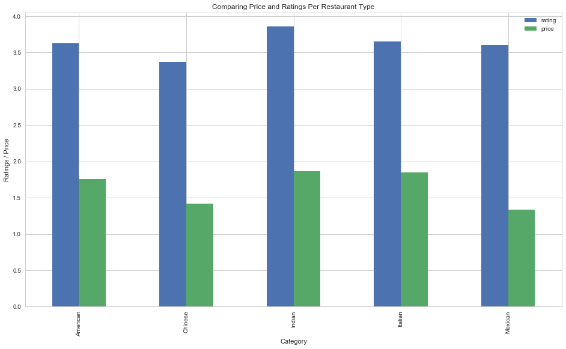

```python
res_df.groupby("category").mean().plot(kind="bar",figsize=(16,9))
plt.xlabel("Category")
plt.ylabel("Ratings / Price")
plt.title("Comparing Price and Ratings Per Restaurant Type")
plt.savefig("Comparing_price_and_ratingcourt.png")
plt.show()
```

### Part 1: Merging Data

Since a large part of our project revolved around correlationg geograpic location and Yelp restaurant data, we needed to merge all the necessary information into one larger dataframe. Thus, we merged res_df with our counties data on the county_string column. This allowed us to pull in and use all the data from both sources.

We then printed res_df as a check to verify contents.

```python
res_df= pd.merge(res_df,counties,how="left",on="county_string")
res_df.head()
```

|  | name | zipcode | county_string | rating | review_count | category | price | region | CensusId | State | ... | OtherTransp | WorkAtHome | MeanCommute | Employed | PrivateWork | PublicWork | SelfEmployed | FamilyWork | Unemployment | Region |
| --- | --- | --- | --- | --- | --- | --- | --- | --- | --- | --- | --- | --- | --- | --- | --- | --- | --- | --- | --- | --- | --- |
| 0 | Cabo Fish Taco | 28205 | Mecklenburg County, North Carolina | 4.0 | 990 | Mexican | 2 | region | 37119 | North Carolina | ... | 1.3 | 6.1 | 25.3 | 502455 | 86.0 | 9.1 | 4.8 | 0.1 | 8.9 | SE |
| 1 | Midwood Smokehouse | 28205 | Mecklenburg County, North Carolina | 4.5 | 1281 | American | 2 | region | 37119 | North Carolina | ... | 1.3 | 6.1 | 25.3 | 502455 | 86.0 | 9.1 | 4.8 | 0.1 | 8.9 | SE |
| 2 | Sabor Latin Street Grill | 28204 | Mecklenburg County, North Carolina | 4.5 | 682 | Mexican | 1 | region | 37119 | North Carolina | ... | 1.3 | 6.1 | 25.3 | 502455 | 86.0 | 9.1 | 4.8 | 0.1 | 8.9 | SE |
| 3 | Benny Pennello's | 28205 | Mecklenburg County, North Carolina | 4.0 | 234 | Italian | 1 | region | 37119 | North Carolina | ... | 1.3 | 6.1 | 25.3 | 502455 | 86.0 | 9.1 | 4.8 | 0.1 | 8.9 | SE |
| 4 | JackBeagles | 28205 | Mecklenburg County, North Carolina | 4.0 | 292 | American | 1 | region | 37119 | North Carolina | ... | 1.3 | 6.1 | 25.3 | 502455 | 86.0 | 9.1 | 4.8 | 0.1 | 8.9 | SE |

5 rows × 46 columns

### Part 2: Examining category distribution across the US

```python
itadf = res_df.groupby(res_df["category"]).get_group("Italian")
mexdf = res_df.groupby(res_df["category"]).get_group("Mexican")
chndf = res_df.groupby(res_df["category"]).get_group("Chinese")
usadf = res_df.groupby(res_df["category"]).get_group("American")
inddf = res_df.groupby(res_df["category"]).get_group("Indian")
res_df
# CHA = res_df.groupby(res_df["county_string"]).get_group("Mecklenburg County, North Carolina")
# CHAbreakdown = pd.DataFrame(CHA["category"].value_counts()).T.reset_index()
# CHAbreakdown["county_string"]="Mecklenburg County, North Carolina"
# CHA_price_avg = CHA.groupby(res_df["price"]).mean()
# CHA_price_count = CHA["price"].value_counts()

# RAL = res_df.groupby(res_df["county_string"]).get_group("Wake County, North Carolina")
# RALbreakdown = pd.DataFrame(RAL["category"].value_counts()).T.reset_index()
# RALbreakdown["county_string"]="Wake County, North Carolina"
# RAL_price_avg = RAL.groupby(res_df["price"]).mean()
# RAL_price_count = RAL["price"].value_counts()

# ATL = res_df.groupby(res_df["county_string"]).get_group("Fulton County, Georgia")
# ATLbreakdown = pd.DataFrame(ATL["category"].value_counts()).T.reset_index()
# ATLbreakdown["county_string"]="Fulton County, Georgia"
# ATL_price_avg = ATL.groupby(res_df["price"]).mean()
# ATL_price_count = ATL["price"].value_counts()

# MEM = res_df.groupby(res_df["county_string"]).get_group("Shelby County, Tennessee")
# MEMbreakdown = pd.DataFrame(MEM["category"].value_counts()).T.reset_index()
# MEMbreakdown["county_string"]="Shelby County, Tennessee"
# MEM_price_avg = MEM.groupby(res_df["price"]).mean()
# MEM_price_count = MEM["price"].value_counts()


# ORL = res_df.groupby(res_df["county_string"]).get_group("Orange County, Florida")
# ORLbreakdown = pd.DataFrame(ORL["category"].value_counts()).T.reset_index()
# ORLbreakdown["county_string"]="Orange County, Florida"
# ORL_price_avg = ORL.groupby(res_df["price"]).mean()
# ORL_price_count = ORL["price"].value_counts()

# MIL = res_df.groupby(res_df["county_string"]).get_group("Milwaukee County, Wisconsin")
# MILbreakdown = pd.DataFrame(MIL["category"].value_counts()).T.reset_index()
# MILbreakdown["county_string"]="Milwaukee County, Wisconsin"
# MIL_price_avg = MIL.groupby(res_df["price"]).mean()
# MIL_price_count = MIL["price"].value_counts()

# SFC = res_df.groupby(res_df["county_string"]).get_group("San Francisco County, California")
# SFCbreakdown = pd.DataFrame(SFC["category"].value_counts()).T.reset_index()
# SFCbreakdown["county_string"]="San Francisco County, California"
# SFC_price_avg = SFC.groupby(res_df["price"]).mean()
# SFC_price_count = SFC["price"].value_counts()

# AUS = res_df.groupby(res_df["county_string"]).get_group("Travis County, Texas")
# AUSbreakdown = pd.DataFrame(AUS["category"].value_counts()).T.reset_index()
# AUSbreakdown["county_string"]="Travis County, Texas"
# AUS_price_avg = AUS.groupby(res_df["price"]).mean()
# AUS_price_count = AUS["price"].value_counts()

# PIT = res_df.groupby(res_df["county_string"]).get_group("Allegheny County, Pennsylvania")
# PITbreakdown = pd.DataFrame(PIT["category"].value_counts()).T.reset_index()
# PITbreakdown["county_string"]="Allegheny County, Pennsylvania"
# PIT_price_avg = PIT.groupby(res_df["price"]).mean()
# PIT_price_count = PIT["price"].value_counts()
```

|  | name | zipcode | county_string | rating | review_count | category | price | region | CensusId | State | ... | OtherTransp | WorkAtHome | MeanCommute | Employed | PrivateWork | PublicWork | SelfEmployed | FamilyWork | Unemployment | Region |
| --- | --- | --- | --- | --- | --- | --- | --- | --- | --- | --- | --- | --- | --- | --- | --- | --- | --- | --- | --- | --- | --- |
| 0 | Cabo Fish Taco | 28205 | Mecklenburg County, North Carolina | 4.0 | 990 | Mexican | 2 | region | 37119 | North Carolina | ... | 1.3 | 6.1 | 25.3 | 502455 | 86.0 | 9.1 | 4.8 | 0.1 | 8.9 | SE |
| 1 | Midwood Smokehouse | 28205 | Mecklenburg County, North Carolina | 4.5 | 1281 | American | 2 | region | 37119 | North Carolina | ... | 1.3 | 6.1 | 25.3 | 502455 | 86.0 | 9.1 | 4.8 | 0.1 | 8.9 | SE |
| 2 | Sabor Latin Street Grill | 28204 | Mecklenburg County, North Carolina | 4.5 | 682 | Mexican | 1 | region | 37119 | North Carolina | ... | 1.3 | 6.1 | 25.3 | 502455 | 86.0 | 9.1 | 4.8 | 0.1 | 8.9 | SE |
| 3 | Benny Pennello's | 28205 | Mecklenburg County, North Carolina | 4.0 | 234 | Italian | 1 | region | 37119 | North Carolina | ... | 1.3 | 6.1 | 25.3 | 502455 | 86.0 | 9.1 | 4.8 | 0.1 | 8.9 | SE |
| 4 | JackBeagles | 28205 | Mecklenburg County, North Carolina | 4.0 | 292 | American | 1 | region | 37119 | North Carolina | ... | 1.3 | 6.1 | 25.3 | 502455 | 86.0 | 9.1 | 4.8 | 0.1 | 8.9 | SE |
| 5 | The Cellar At Duckworth's | 28202 | Mecklenburg County, North Carolina | 4.5 | 361 | American | 2 | region | 37119 | North Carolina | ... | 1.3 | 6.1 | 25.3 | 502455 | 86.0 | 9.1 | 4.8 | 0.1 | 8.9 | SE |
| 6 | Pinky's Westside Grill | 28208 | Mecklenburg County, North Carolina | 4.0 | 856 | American | 1 | region | 37119 | North Carolina | ... | 1.3 | 6.1 | 25.3 | 502455 | 86.0 | 9.1 | 4.8 | 0.1 | 8.9 | SE |
| 7 | The Fig Tree Restaurant | 28204 | Mecklenburg County, North Carolina | 4.5 | 343 | American | 3 | region | 37119 | North Carolina | ... | 1.3 | 6.1 | 25.3 | 502455 | 86.0 | 9.1 | 4.8 | 0.1 | 8.9 | SE |
| 8 | VBGB Beer Hall and Garden | 28206 | Mecklenburg County, North Carolina | 4.5 | 326 | American | 2 | region | 37119 | North Carolina | ... | 1.3 | 6.1 | 25.3 | 502455 | 86.0 | 9.1 | 4.8 | 0.1 | 8.9 | SE |
| 9 | Dandelion Market | 28202 | Mecklenburg County, North Carolina | 4.0 | 553 | American | 2 | region | 37119 | North Carolina | ... | 1.3 | 6.1 | 25.3 | 502455 | 86.0 | 9.1 | 4.8 | 0.1 | 8.9 | SE |
| 10 | Growlers Pourhouse | 28205 | Mecklenburg County, North Carolina | 4.0 | 201 | American | 2 | region | 37119 | North Carolina | ... | 1.3 | 6.1 | 25.3 | 502455 | 86.0 | 9.1 | 4.8 | 0.1 | 8.9 | SE |
| 11 | Alexander Michael's | 28202 | Mecklenburg County, North Carolina | 4.5 | 331 | American | 2 | region | 37119 | North Carolina | ... | 1.3 | 6.1 | 25.3 | 502455 | 86.0 | 9.1 | 4.8 | 0.1 | 8.9 | SE |
| 12 | Sabor Latin Street Grill - Noda | 28205 | Mecklenburg County, North Carolina | 4.5 | 155 | Mexican | 1 | region | 37119 | North Carolina | ... | 1.3 | 6.1 | 25.3 | 502455 | 86.0 | 9.1 | 4.8 | 0.1 | 8.9 | SE |
| 13 | Tupelo Honey | 28203 | Mecklenburg County, North Carolina | 4.0 | 1180 | American | 2 | region | 37119 | North Carolina | ... | 1.3 | 6.1 | 25.3 | 502455 | 86.0 | 9.1 | 4.8 | 0.1 | 8.9 | SE |
| 14 | The King's Kitchen | 28202 | Mecklenburg County, North Carolina | 4.0 | 484 | American | 2 | region | 37119 | North Carolina | ... | 1.3 | 6.1 | 25.3 | 502455 | 86.0 | 9.1 | 4.8 | 0.1 | 8.9 | SE |
| 15 | Davidson Street Public House | 28205 | Mecklenburg County, North Carolina | 4.0 | 136 | American | 2 | region | 37119 | North Carolina | ... | 1.3 | 6.1 | 25.3 | 502455 | 86.0 | 9.1 | 4.8 | 0.1 | 8.9 | SE |
| 16 | Three Amigos Mexican Restaurant and Cantina | 28205 | Mecklenburg County, North Carolina | 4.0 | 375 | Mexican | 1 | region | 37119 | North Carolina | ... | 1.3 | 6.1 | 25.3 | 502455 | 86.0 | 9.1 | 4.8 | 0.1 | 8.9 | SE |
| 17 | 300 East | 28203 | Mecklenburg County, North Carolina | 4.0 | 582 | American | 2 | region | 37119 | North Carolina | ... | 1.3 | 6.1 | 25.3 | 502455 | 86.0 | 9.1 | 4.8 | 0.1 | 8.9 | SE |
| 18 | Rooster's Uptown | 28202 | Mecklenburg County, North Carolina | 4.0 | 402 | American | 2 | region | 37119 | North Carolina | ... | 1.3 | 6.1 | 25.3 | 502455 | 86.0 | 9.1 | 4.8 | 0.1 | 8.9 | SE |
| 19 | Las Lupitas | 28213 | Mecklenburg County, North Carolina | 4.5 | 49 | Mexican | 1 | region | 37119 | North Carolina | ... | 1.3 | 6.1 | 25.3 | 502455 | 86.0 | 9.1 | 4.8 | 0.1 | 8.9 | SE |
| 20 | 5Church | 28202 | Mecklenburg County, North Carolina | 3.5 | 575 | American | 2 | region | 37119 | North Carolina | ... | 1.3 | 6.1 | 25.3 | 502455 | 86.0 | 9.1 | 4.8 | 0.1 | 8.9 | SE |
| 21 | Good Food on Montford | 28209 | Mecklenburg County, North Carolina | 4.5 | 582 | American | 2 | region | 37119 | North Carolina | ... | 1.3 | 6.1 | 25.3 | 502455 | 86.0 | 9.1 | 4.8 | 0.1 | 8.9 | SE |
| 22 | Mimosa Grill | 28202 | Mecklenburg County, North Carolina | 4.0 | 426 | American | 2 | region | 37119 | North Carolina | ... | 1.3 | 6.1 | 25.3 | 502455 | 86.0 | 9.1 | 4.8 | 0.1 | 8.9 | SE |
| 23 | The Asbury | 28202 | Mecklenburg County, North Carolina | 4.0 | 205 | American | 2 | region | 37119 | North Carolina | ... | 1.3 | 6.1 | 25.3 | 502455 | 86.0 | 9.1 | 4.8 | 0.1 | 8.9 | SE |
| 24 | Midnight Diner | 28202 | Mecklenburg County, North Carolina | 4.0 | 612 | American | 1 | region | 37119 | North Carolina | ... | 1.3 | 6.1 | 25.3 | 502455 | 86.0 | 9.1 | 4.8 | 0.1 | 8.9 | SE |
| 25 | Mama Ricotta's | 28204 | Mecklenburg County, North Carolina | 4.0 | 415 | Italian | 2 | region | 37119 | North Carolina | ... | 1.3 | 6.1 | 25.3 | 502455 | 86.0 | 9.1 | 4.8 | 0.1 | 8.9 | SE |
| 26 | Papi Queso | 28202 | Mecklenburg County, North Carolina | 4.5 | 127 | American | 1 | region | 37119 | North Carolina | ... | 1.3 | 6.1 | 25.3 | 502455 | 86.0 | 9.1 | 4.8 | 0.1 | 8.9 | SE |
| 27 | Lebowski's Neighborhood Grill | 28203 | Mecklenburg County, North Carolina | 4.5 | 335 | American | 2 | region | 37119 | North Carolina | ... | 1.3 | 6.1 | 25.3 | 502455 | 86.0 | 9.1 | 4.8 | 0.1 | 8.9 | SE |
| 28 | Carpe Diem Restaurant & Caterers | 28204 | Mecklenburg County, North Carolina | 4.0 | 174 | American | 3 | region | 37119 | North Carolina | ... | 1.3 | 6.1 | 25.3 | 502455 | 86.0 | 9.1 | 4.8 | 0.1 | 8.9 | SE |
| 29 | JJ's Red Hots - Dilworth | 28203 | Mecklenburg County, North Carolina | 4.0 | 349 | American | 1 | region | 37119 | North Carolina | ... | 1.3 | 6.1 | 25.3 | 502455 | 86.0 | 9.1 | 4.8 | 0.1 | 8.9 | SE |
| ... | ... | ... | ... | ... | ... | ... | ... | ... | ... | ... | ... | ... | ... | ... | ... | ... | ... | ... | ... | ... | ... |
| 2051 | Pizza Hut | 19901 | Kent County, Delaware | 2.0 | 12 | Italian | 2 | region | 10001 | Delaware | ... | 1.0 | 3.6 | 26.1 | 75246 | 73.4 | 22.4 | 3.9 | 0.3 | 8.4 | NE |
| 2052 | Panda Express | 19901 | Kent County, Delaware | 2.0 | 9 | Chinese | 1 | region | 10001 | Delaware | ... | 1.0 | 3.6 | 26.1 | 75246 | 73.4 | 22.4 | 3.9 | 0.3 | 8.4 | NE |
| 2053 | Chovy's Italian Casual | 16335 | Crawford County, Pennsylvania | 3.5 | 57 | Italian | 2 | region | 42039 | Pennsylvania | ... | 1.4 | 4.5 | 21.7 | 37783 | 80.0 | 11.2 | 8.5 | 0.3 | 7.2 | NE |
| 2054 | Market House Grille | 16335 | Crawford County, Pennsylvania | 4.0 | 23 | American | 1 | region | 42039 | Pennsylvania | ... | 1.4 | 4.5 | 21.7 | 37783 | 80.0 | 11.2 | 8.5 | 0.3 | 7.2 | NE |
| 2055 | Julian's Bar & Grill | 16335 | Crawford County, Pennsylvania | 4.0 | 21 | American | 2 | region | 42039 | Pennsylvania | ... | 1.4 | 4.5 | 21.7 | 37783 | 80.0 | 11.2 | 8.5 | 0.3 | 7.2 | NE |
| 2056 | Timber Creek Tap & Table | 16335 | Crawford County, Pennsylvania | 3.5 | 89 | American | 2 | region | 42039 | Pennsylvania | ... | 1.4 | 4.5 | 21.7 | 37783 | 80.0 | 11.2 | 8.5 | 0.3 | 7.2 | NE |
| 2057 | Mannino Italian Garden | 16335 | Crawford County, Pennsylvania | 4.5 | 11 | Italian | 2 | region | 42039 | Pennsylvania | ... | 1.4 | 4.5 | 21.7 | 37783 | 80.0 | 11.2 | 8.5 | 0.3 | 7.2 | NE |
| 2058 | Cracker Barrel Old Country Store | 16335 | Crawford County, Pennsylvania | 3.0 | 23 | American | 2 | region | 42039 | Pennsylvania | ... | 1.4 | 4.5 | 21.7 | 37783 | 80.0 | 11.2 | 8.5 | 0.3 | 7.2 | NE |
| 2059 | Valenza Restaurant | 16335 | Crawford County, Pennsylvania | 4.0 | 11 | Italian | 1 | region | 42039 | Pennsylvania | ... | 1.4 | 4.5 | 21.7 | 37783 | 80.0 | 11.2 | 8.5 | 0.3 | 7.2 | NE |
| 2060 | Super China Buffet | 16335 | Crawford County, Pennsylvania | 3.5 | 7 | Chinese | 1 | region | 42039 | Pennsylvania | ... | 1.4 | 4.5 | 21.7 | 37783 | 80.0 | 11.2 | 8.5 | 0.3 | 7.2 | NE |
| 2061 | Firehouse Tap & Grille | 16335 | Crawford County, Pennsylvania | 4.0 | 8 | American | 3 | region | 42039 | Pennsylvania | ... | 1.4 | 4.5 | 21.7 | 37783 | 80.0 | 11.2 | 8.5 | 0.3 | 7.2 | NE |
| 2062 | Hunter's Inn | 16335 | Crawford County, Pennsylvania | 5.0 | 8 | American | 2 | region | 42039 | Pennsylvania | ... | 1.4 | 4.5 | 21.7 | 37783 | 80.0 | 11.2 | 8.5 | 0.3 | 7.2 | NE |
| 2063 | Chestnut St Pub & Grill | 16335 | Crawford County, Pennsylvania | 4.5 | 3 | American | 1 | region | 42039 | Pennsylvania | ... | 1.4 | 4.5 | 21.7 | 37783 | 80.0 | 11.2 | 8.5 | 0.3 | 7.2 | NE |
| 2064 | Dave's Place | 16360 | Crawford County, Pennsylvania | 4.5 | 4 | American | 1 | region | 42039 | Pennsylvania | ... | 1.4 | 4.5 | 21.7 | 37783 | 80.0 | 11.2 | 8.5 | 0.3 | 7.2 | NE |
| 2065 | Applebee's Grill + Bar | 16335 | Crawford County, Pennsylvania | 3.0 | 9 | American | 2 | region | 42039 | Pennsylvania | ... | 1.4 | 4.5 | 21.7 | 37783 | 80.0 | 11.2 | 8.5 | 0.3 | 7.2 | NE |
| 2066 | Pizza Hut | 16335 | Crawford County, Pennsylvania | 2.5 | 3 | Italian | 1 | region | 42039 | Pennsylvania | ... | 1.4 | 4.5 | 21.7 | 37783 | 80.0 | 11.2 | 8.5 | 0.3 | 7.2 | NE |
| 2067 | Deer Head Inn | 16335 | Crawford County, Pennsylvania | 3.0 | 3 | American | 1 | region | 42039 | Pennsylvania | ... | 1.4 | 4.5 | 21.7 | 37783 | 80.0 | 11.2 | 8.5 | 0.3 | 7.2 | NE |
| 2068 | New Imperial Chinese Buffet | 16335 | Crawford County, Pennsylvania | 2.0 | 5 | Chinese | 1 | region | 42039 | Pennsylvania | ... | 1.4 | 4.5 | 21.7 | 37783 | 80.0 | 11.2 | 8.5 | 0.3 | 7.2 | NE |
| 2069 | Red Lobster | 16335 | Crawford County, Pennsylvania | 3.5 | 5 | American | 3 | region | 42039 | Pennsylvania | ... | 1.4 | 4.5 | 21.7 | 37783 | 80.0 | 11.2 | 8.5 | 0.3 | 7.2 | NE |
| 2070 | Perkins Restaurant & Bakery | 16335 | Crawford County, Pennsylvania | 3.0 | 5 | American | 2 | region | 42039 | Pennsylvania | ... | 1.4 | 4.5 | 21.7 | 37783 | 80.0 | 11.2 | 8.5 | 0.3 | 7.2 | NE |
| 2071 | Taco Bell | 16335 | Crawford County, Pennsylvania | 5.0 | 1 | Mexican | 1 | region | 42039 | Pennsylvania | ... | 1.4 | 4.5 | 21.7 | 37783 | 80.0 | 11.2 | 8.5 | 0.3 | 7.2 | NE |
| 2072 | Peter's Europa House | 18458 | Pike County, Pennsylvania | 4.5 | 53 | Italian | 2 | region | 42103 | Pennsylvania | ... | 0.7 | 4.2 | 44.0 | 24320 | 78.1 | 13.6 | 8.0 | 0.3 | 11.6 | NE |
| 2073 | Carini Pizza and Pasta | 18428 | Pike County, Pennsylvania | 3.5 | 24 | Italian | 2 | region | 42103 | Pennsylvania | ... | 0.7 | 4.2 | 44.0 | 24320 | 78.1 | 13.6 | 8.0 | 0.3 | 11.6 | NE |
| 2074 | Pie's On | 18328 | Pike County, Pennsylvania | 3.0 | 30 | American | 2 | region | 42103 | Pennsylvania | ... | 0.7 | 4.2 | 44.0 | 24320 | 78.1 | 13.6 | 8.0 | 0.3 | 11.6 | NE |
| 2075 | The White Pine Inn | 18435 | Pike County, Pennsylvania | 4.0 | 12 | American | 2 | region | 42103 | Pennsylvania | ... | 0.7 | 4.2 | 44.0 | 24320 | 78.1 | 13.6 | 8.0 | 0.3 | 11.6 | NE |
| 2076 | Chris & Ginas Café | 18328 | Pike County, Pennsylvania | 4.5 | 13 | American | 2 | region | 42103 | Pennsylvania | ... | 0.7 | 4.2 | 44.0 | 24320 | 78.1 | 13.6 | 8.0 | 0.3 | 11.6 | NE |
| 2077 | Panda Garden | 18428 | Pike County, Pennsylvania | 3.0 | 7 | Chinese | 2 | region | 42103 | Pennsylvania | ... | 0.7 | 4.2 | 44.0 | 24320 | 78.1 | 13.6 | 8.0 | 0.3 | 11.6 | NE |
| 2078 | The 402 Cafe | 18428 | Pike County, Pennsylvania | 2.0 | 17 | American | 2 | region | 42103 | Pennsylvania | ... | 0.7 | 4.2 | 44.0 | 24320 | 78.1 | 13.6 | 8.0 | 0.3 | 11.6 | NE |
| 2079 | China Delight | 18328 | Pike County, Pennsylvania | 2.0 | 13 | Chinese | 1 | region | 42103 | Pennsylvania | ... | 0.7 | 4.2 | 44.0 | 24320 | 78.1 | 13.6 | 8.0 | 0.3 | 11.6 | NE |
| 2080 | China Dynasty Restaurant | 18428 | Pike County, Pennsylvania | 3.0 | 2 | Chinese | 1 | region | 42103 | Pennsylvania | ... | 0.7 | 4.2 | 44.0 | 24320 | 78.1 | 13.6 | 8.0 | 0.3 | 11.6 | NE |

2081 rows × 46 columns

### Part 2: Examining category distribution across the US

```python
TOTAL_price_avg = res_df.groupby(["price"]).mean()
rescount = res_df.groupby(["county_string"]).count()["name"].reset_index()
rescount.columns=['county_string', 'restaurant_count']
TOTAL_county_reviews = res_df.groupby(["county_string"]).review_count.sum().reset_index()
TOTAL_county_reviews.columns=["county_string","review_count"]
TOTAL_county_avg = res_df.groupby(res_df["county_string"]).mean().reset_index()

county_stats = TOTAL_county_avg.merge(TOTAL_county_reviews, on="county_string")
csdf = county_stats.merge(counties, on="county_string")
c_df = rescount.merge(csdf, on="county_string")
c_df
```

|  | county_string | restaurant_count | rating | price | CensusId_x | TotalPop_x | Men_x | Women_x | Hispanic_x | White_x | ... | OtherTransp_y | WorkAtHome_y | MeanCommute_y | Employed_y | PrivateWork_y | PublicWork_y | SelfEmployed_y | FamilyWork_y | Unemployment_y | Region |
| --- | --- | --- | --- | --- | --- | --- | --- | --- | --- | --- | --- | --- | --- | --- | --- | --- | --- | --- | --- | --- | --- |
| 0 | Barry County, Missouri | 4 | 3.750000 | 1.250000 | 29009.0 | 35726.0 | 17905.0 | 17821.0 | 8.5 | 87.2 | ... | 1.0 | 4.2 | 22.5 | 14259 | 78.2 | 11.6 | 10.2 | 0.0 | 11.4 | MW |
| 1 | Bee County, Texas | 10 | 3.200000 | 1.600000 | 48025.0 | 32659.0 | 19722.0 | 12937.0 | 57.3 | 33.1 | ... | 1.5 | 1.9 | 23.0 | 10451 | 70.5 | 22.7 | 6.7 | 0.2 | 7.0 | SW |
| 2 | Boone County, Missouri | 123 | 3.418699 | 1.601626 | 29019.0 | 170770.0 | 82533.0 | 88237.0 | 3.2 | 80.0 | ... | 2.0 | 3.9 | 18.1 | 90949 | 71.4 | 24.0 | 4.4 | 0.1 | 5.0 | MW |
| 3 | Buncombe County, North Carolina | 201 | 3.753731 | 1.691542 | 37021.0 | 247336.0 | 118950.0 | 128386.0 | 6.4 | 83.8 | ... | 1.0 | 7.1 | 20.3 | 117252 | 79.0 | 12.4 | 8.4 | 0.3 | 7.0 | SE |
| 4 | Citrus County, Florida | 51 | 3.647059 | 1.549020 | 12017.0 | 139654.0 | 67381.0 | 72273.0 | 5.1 | 88.9 | ... | 2.5 | 5.6 | 24.9 | 43486 | 78.2 | 14.4 | 6.9 | 0.5 | 13.1 | SE |
| 5 | Clackamas County, Oregon | 31 | 4.064516 | 1.645161 | 41005.0 | 389438.0 | 191639.0 | 197799.0 | 8.2 | 83.4 | ... | 1.5 | 7.2 | 27.7 | 185660 | 80.9 | 11.1 | 7.8 | 0.2 | 8.3 | WC |
| 6 | Columbia County, New York | 21 | 3.452381 | 1.666667 | 36021.0 | 62195.0 | 31244.0 | 30951.0 | 4.3 | 87.5 | ... | 0.7 | 6.7 | 26.0 | 29962 | 71.0 | 19.8 | 8.9 | 0.3 | 6.7 | NE |
| 7 | Crawford County, Pennsylvania | 19 | 3.684211 | 1.631579 | 42039.0 | 87343.0 | 42688.0 | 44655.0 | 1.2 | 95.2 | ... | 1.4 | 4.5 | 21.7 | 37783 | 80.0 | 11.2 | 8.5 | 0.3 | 7.2 | NE |
| 8 | Crockett County, Tennessee | 1 | 3.000000 | 2.000000 | 47033.0 | 14600.0 | 6906.0 | 7694.0 | 9.5 | 75.7 | ... | 0.5 | 3.7 | 23.4 | 5766 | 77.7 | 14.3 | 7.9 | 0.1 | 7.4 | SE |
| 9 | East Feliciana County, Louisiana | 3 | 3.833333 | 1.333333 | 22037.0 | 19855.0 | 10666.0 | 9189.0 | 1.3 | 52.8 | ... | 0.6 | 2.7 | 33.0 | 7165 | 68.3 | 26.1 | 5.6 | 0.0 | 6.5 | SE |
| 10 | Erie County, New York | 109 | 3.532110 | 1.715596 | 36029.0 | 921584.0 | 445761.0 | 475823.0 | 5.0 | 76.6 | ... | 1.3 | 2.6 | 21.2 | 441369 | 79.2 | 16.8 | 4.0 | 0.1 | 7.0 | NE |
| 11 | Essex County, New York | 3 | 3.333333 | 1.666667 | 36031.0 | 38912.0 | 20283.0 | 18629.0 | 3.0 | 92.2 | ... | 3.7 | 5.3 | 20.8 | 17769 | 70.2 | 20.4 | 9.2 | 0.3 | 7.9 | NE |
| 12 | Franklin County, Florida | 3 | 3.500000 | 1.333333 | 12037.0 | 11628.0 | 6800.0 | 4828.0 | 5.0 | 78.6 | ... | 3.2 | 5.4 | 20.3 | 4331 | 58.9 | 26.1 | 14.9 | 0.1 | 9.4 | SE |
| 13 | Gallia County, Ohio | 3 | 3.666667 | 1.333333 | 39053.0 | 30565.0 | 14900.0 | 15665.0 | 1.2 | 93.7 | ... | 1.1 | 3.0 | 26.8 | 11344 | 81.3 | 13.1 | 5.5 | 0.2 | 7.5 | MW |
| 14 | Geneva County, Alabama | 1 | 2.500000 | 2.000000 | 1061.0 | 26815.0 | 13174.0 | 13641.0 | 3.6 | 84.0 | ... | 1.8 | 3.4 | 25.8 | 10419 | 75.7 | 15.0 | 8.8 | 0.4 | 11.2 | SE |
| 15 | Graves County, Kentucky | 10 | 3.650000 | 1.500000 | 21083.0 | 37502.0 | 18263.0 | 19239.0 | 5.9 | 87.2 | ... | 1.5 | 4.9 | 23.2 | 15840 | 77.0 | 14.3 | 8.6 | 0.0 | 7.2 | MW |
| 16 | Hamilton County, Kansas | 2 | 4.500000 | 1.000000 | 20075.0 | 2586.0 | 1342.0 | 1244.0 | 33.7 | 64.7 | ... | 0.0 | 8.3 | 12.5 | 1322 | 64.8 | 16.6 | 17.9 | 0.7 | 2.3 | MW |
| 17 | Hamilton County, Texas | 6 | 4.333333 | 1.000000 | 48193.0 | 8266.0 | 4040.0 | 4226.0 | 11.2 | 86.4 | ... | 0.5 | 3.6 | 21.0 | 3279 | 72.9 | 17.8 | 7.5 | 1.9 | 5.9 | SW |
| 18 | Henderson County, Texas | 26 | 3.596154 | 1.538462 | 48213.0 | 79016.0 | 38598.0 | 40418.0 | 11.7 | 79.5 | ... | 0.7 | 3.8 | 28.5 | 30441 | 75.6 | 13.9 | 10.4 | 0.1 | 7.8 | SW |
| 19 | Jefferson County, Washington | 2 | 4.250000 | 2.000000 | 53031.0 | 30083.0 | 14850.0 | 15233.0 | 3.4 | 88.7 | ... | 2.6 | 8.7 | 22.6 | 11518 | 66.9 | 18.2 | 14.8 | 0.1 | 9.5 | WC |
| 20 | Kent County, Delaware | 67 | 3.283582 | 1.686567 | 10001.0 | 169509.0 | 81716.0 | 87793.0 | 6.5 | 63.7 | ... | 1.0 | 3.6 | 26.1 | 75246 | 73.4 | 22.4 | 3.9 | 0.3 | 8.4 | NE |
| 21 | Kitsap County, Washington | 78 | 3.455128 | 1.705128 | 53035.0 | 255441.0 | 130126.0 | 125315.0 | 7.1 | 77.7 | ... | 2.3 | 6.9 | 29.9 | 107745 | 65.3 | 27.6 | 7.0 | 0.1 | 8.0 | WC |
| 22 | Linn County, Oregon | 39 | 3.833333 | 1.641026 | 41043.0 | 118971.0 | 58803.0 | 60168.0 | 8.3 | 86.4 | ... | 2.0 | 5.8 | 22.8 | 48892 | 77.7 | 15.5 | 6.6 | 0.1 | 10.6 | WC |
| 23 | Mecklenburg County, North Carolina | 334 | 3.591317 | 1.658683 | 37119.0 | 990288.0 | 476765.0 | 513523.0 | 12.5 | 49.1 | ... | 1.3 | 6.1 | 25.3 | 502455 | 86.0 | 9.1 | 4.8 | 0.1 | 8.9 | SE |
| 24 | Montgomery County, Kansas | 5 | 3.900000 | 1.800000 | 20125.0 | 34184.0 | 16851.0 | 17333.0 | 6.0 | 80.4 | ... | 1.7 | 1.8 | 16.8 | 14514 | 77.9 | 15.0 | 6.8 | 0.3 | 8.7 | MW |
| 25 | Moody County, South Dakota | 1 | 3.000000 | 1.000000 | 46101.0 | 6439.0 | 3227.0 | 3212.0 | 3.0 | 79.1 | ... | 2.5 | 7.9 | 19.2 | 3379 | 66.0 | 18.6 | 14.8 | 0.5 | 6.1 | MW |
| 26 | Morrow County, Oregon | 6 | 3.583333 | 1.333333 | 41049.0 | 11204.0 | 5800.0 | 5404.0 | 34.0 | 62.0 | ... | 1.0 | 6.7 | 18.6 | 4827 | 77.3 | 15.5 | 7.2 | 0.0 | 8.6 | WC |
| 27 | Osage County, Oklahoma | 4 | 4.000000 | 1.500000 | 40113.0 | 48054.0 | 24068.0 | 23986.0 | 3.2 | 64.3 | ... | 1.0 | 2.2 | 24.7 | 19274 | 77.0 | 17.1 | 5.9 | 0.0 | 7.1 | SW |
| 28 | Pend Oreille County, Washington | 9 | 3.944444 | 1.555556 | 53051.0 | 12968.0 | 6665.0 | 6303.0 | 3.5 | 89.2 | ... | 1.4 | 7.8 | 30.7 | 4217 | 62.5 | 26.5 | 10.4 | 0.7 | 10.3 | WC |
| 29 | Pike County, Pennsylvania | 9 | 3.277778 | 1.777778 | 42103.0 | 56632.0 | 28249.0 | 28383.0 | 9.9 | 81.8 | ... | 0.7 | 4.2 | 44.0 | 24320 | 78.1 | 13.6 | 8.0 | 0.3 | 11.6 | NE |
| 30 | Providence County, Rhode Island | 238 | 3.766807 | 1.663866 | 44007.0 | 630459.0 | 305247.0 | 325212.0 | 20.3 | 64.0 | ... | 1.9 | 3.0 | 23.9 | 301318 | 84.6 | 11.3 | 4.1 | 0.1 | 9.5 | NE |
| 31 | Pueblo County, Colorado | 3 | 2.833333 | 1.333333 | 8101.0 | 161519.0 | 79535.0 | 81984.0 | 42.3 | 53.0 | ... | 1.2 | 3.0 | 21.1 | 65300 | 76.6 | 18.7 | 4.5 | 0.2 | 10.8 | SW |
| 32 | Randall County, Texas | 9 | 3.222222 | 1.333333 | 48381.0 | 126782.0 | 62256.0 | 64526.0 | 18.8 | 75.0 | ... | 0.7 | 2.7 | 19.1 | 65270 | 75.4 | 17.5 | 7.1 | 0.1 | 3.9 | SW |
| 33 | Rice County, Minnesota | 25 | 3.880000 | 1.520000 | 27131.0 | 64886.0 | 33038.0 | 31848.0 | 7.8 | 84.4 | ... | 2.1 | 13.2 | 22.7 | 33503 | 82.4 | 10.8 | 6.5 | 0.3 | 5.6 | MW |
| 34 | Runnels County, Texas | 6 | 4.083333 | 1.333333 | 48399.0 | 10445.0 | 5181.0 | 5264.0 | 33.6 | 62.8 | ... | 0.4 | 4.3 | 18.1 | 4292 | 67.7 | 19.9 | 12.1 | 0.4 | 3.4 | SW |
| 35 | San Benito County, California | 32 | 3.843750 | 1.656250 | 6069.0 | 57557.0 | 28773.0 | 28784.0 | 57.9 | 36.6 | ... | 1.5 | 3.5 | 31.8 | 26261 | 76.4 | 16.3 | 7.1 | 0.3 | 12.2 | WC |
| 36 | Santa Cruz County, California | 184 | 3.529891 | 1.706522 | 6087.0 | 269278.0 | 133714.0 | 135564.0 | 32.9 | 58.3 | ... | 6.6 | 7.3 | 25.9 | 131321 | 73.1 | 15.3 | 11.4 | 0.2 | 7.6 | WC |
| 37 | Scott County, Indiana | 10 | 3.150000 | 1.400000 | 18143.0 | 23783.0 | 11685.0 | 12098.0 | 1.7 | 96.4 | ... | 1.7 | 2.5 | 24.9 | 9803 | 84.6 | 11.7 | 3.4 | 0.3 | 11.0 | MW |
| 38 | Shoshone County, Idaho | 20 | 4.050000 | 1.750000 | 16079.0 | 12571.0 | 6324.0 | 6247.0 | 3.3 | 92.4 | ... | 1.9 | 5.7 | 18.4 | 4992 | 76.9 | 15.8 | 6.8 | 0.4 | 11.8 | WC |
| 39 | Strafford County, New Hampshire | 30 | 3.233333 | 1.633333 | 33017.0 | 125273.0 | 61104.0 | 64169.0 | 2.1 | 91.9 | ... | 1.4 | 4.3 | 26.8 | 66369 | 79.0 | 15.6 | 5.3 | 0.0 | 6.5 | NE |
| 40 | Summit County, Ohio | 224 | 3.448661 | 1.584821 | 39153.0 | 541847.0 | 262467.0 | 279380.0 | 1.8 | 78.6 | ... | 0.5 | 2.9 | 22.9 | 258416 | 84.2 | 11.2 | 4.5 | 0.1 | 8.4 | MW |
| 41 | Sussex County, Delaware | 17 | 3.852941 | 1.529412 | 10005.0 | 207302.0 | 100782.0 | 106520.0 | 9.2 | 74.8 | ... | 1.6 | 4.9 | 25.0 | 90239 | 78.8 | 14.7 | 6.4 | 0.1 | 8.0 | NE |
| 42 | Texas County, Oklahoma | 10 | 3.500000 | 1.500000 | 40139.0 | 21588.0 | 11340.0 | 10248.0 | 45.2 | 47.7 | ... | 1.0 | 1.6 | 17.5 | 11144 | 78.7 | 15.5 | 5.4 | 0.3 | 3.5 | SW |
| 43 | Warren County, Tennessee | 14 | 3.285714 | 1.357143 | 47177.0 | 40015.0 | 19801.0 | 20214.0 | 8.4 | 86.5 | ... | 1.1 | 3.3 | 24.0 | 16304 | 77.3 | 14.1 | 8.1 | 0.5 | 8.0 | SE |
| 44 | Wasco County, Oregon | 3 | 4.166667 | 2.000000 | 41065.0 | 25492.0 | 12634.0 | 12858.0 | 16.5 | 76.1 | ... | 1.6 | 7.5 | 16.0 | 10907 | 74.8 | 16.8 | 8.3 | 0.1 | 9.0 | WC |
| 45 | Westmoreland County, Pennsylvania | 66 | 3.681818 | 1.848485 | 42129.0 | 361251.0 | 176227.0 | 185024.0 | 1.0 | 94.3 | ... | 0.7 | 3.6 | 26.7 | 173533 | 85.4 | 9.3 | 5.2 | 0.1 | 5.6 | NE |
| 46 | Wood County, Texas | 3 | 4.166667 | 1.333333 | 48499.0 | 42712.0 | 21159.0 | 21553.0 | 9.4 | 83.7 | ... | 1.1 | 6.1 | 29.0 | 15868 | 75.0 | 15.6 | 9.0 | 0.4 | 8.9 | SW |
| 47 | Yazoo County, Mississippi | 6 | 3.750000 | 1.500000 | 28163.0 | 27911.0 | 15460.0 | 12451.0 | 4.8 | 36.5 | ... | 0.5 | 3.0 | 28.0 | 8382 | 70.4 | 21.1 | 8.1 | 0.3 | 19.8 | SE |

48 rows × 78 columns

```python
current_county="Mecklenburg County, North Carolina"
WCO = res_df.groupby(res_df["county_string"]).get_group(current_county)
WCObreakdown = pd.DataFrame(WCO["category"].value_counts()).T.reset_index()
WCOrate = pd.DataFrame(WCO["rating"].value_counts()).T.reset_index()
WCObreakdown["county_string"]=current_county
WCO_price_avg = WCO.groupby(res_df["price"]).mean()
WCO_price_count = WCO["price"].value_counts()
WCObreakdown
```

|  | index | American | Mexican | Italian | Chinese | Indian | county_string |
| --- | --- | --- | --- | --- | --- | --- | --- |
| 0 | category | 176 | 70 | 42 | 33 | 13 | Mecklenburg County, North Carolina |

```python
comp_df = pd.DataFrame(columns=["Italian","Mexican","Chinese","American", "Indian","county_string"])
comp_df = comp_df.append(WCObreakdown)
comp_df = comp_df.append(WCObreakdown)
comp_df = comp_df.append(WCObreakdown)
comp_df = comp_df.append(WCObreakdown)
comp_df = comp_df.append(WCObreakdown)
comp_df = comp_df.append(WCObreakdown)
comp_df = comp_df.append(WCObreakdown)
comp_df = comp_df.append(WCObreakdown)
comp_df = comp_df.append(WCObreakdown)
comp_df = comp_df.reset_index()
del comp_df["index"]
del comp_df["level_0"]
#comp_df["Totals"]=comp_df["Italian"]+comp_df["Mexican"]+comp_df["Chinese"]+comp_df["Indian"]+comp_df["American"]
comp_df
```

|  | American | Chinese | Indian | Italian | Mexican | county_string |
| --- | --- | --- | --- | --- | --- | --- |
| 0 | 176 | 33 | 13 | 42 | 70 | Mecklenburg County, North Carolina |
| 1 | 176 | 33 | 13 | 42 | 70 | Mecklenburg County, North Carolina |
| 2 | 176 | 33 | 13 | 42 | 70 | Mecklenburg County, North Carolina |
| 3 | 176 | 33 | 13 | 42 | 70 | Mecklenburg County, North Carolina |
| 4 | 176 | 33 | 13 | 42 | 70 | Mecklenburg County, North Carolina |
| 5 | 176 | 33 | 13 | 42 | 70 | Mecklenburg County, North Carolina |
| 6 | 176 | 33 | 13 | 42 | 70 | Mecklenburg County, North Carolina |
| 7 | 176 | 33 | 13 | 42 | 70 | Mecklenburg County, North Carolina |
| 8 | 176 | 33 | 13 | 42 | 70 | Mecklenburg County, North Carolina |

### Part 2: Examining category distribution across the US

Next, Kyrus generated a for loop to create multiple pie charts representing the categorical breakdown by count

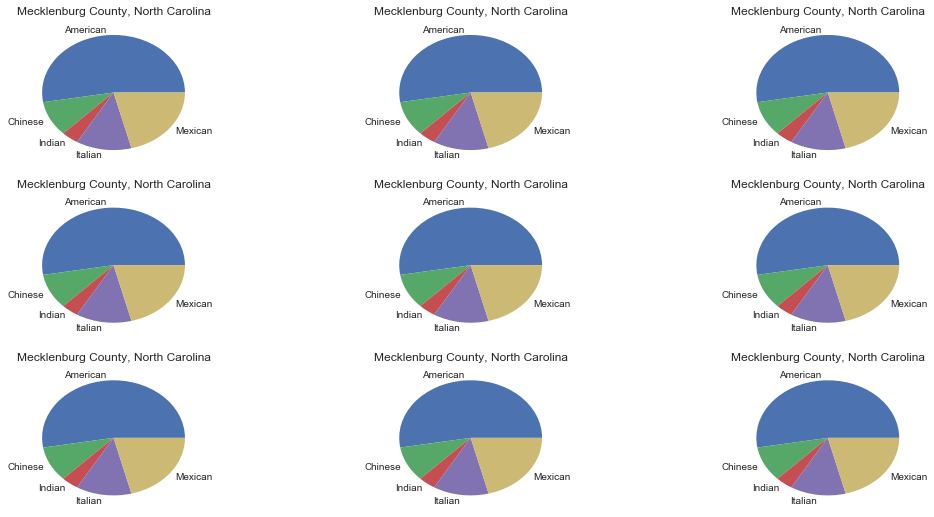

```python
fig, axes = plt.subplots(3,3,figsize= (16,9))
for i, (idx, row) in enumerate(comp_df.set_index("county_string").iterrows()):
    ax = axes[i // 3, i % 3]
    row = row[row.gt(row.sum()*.01)]
    ax.pie(row, labels=row.index)
    ax.set_title(idx)
fig.subplots_adjust(wspace=1)
```

```python
plt.show()
```

### Part 3: Examining price breakdown based on region and restaurant category

**The RQ:** How does price rating (\$, \$\$, \$\$\$, \$\$\$\$) breakdown for our randomly pulled cities? What is a the price rating breakdown by specific region and restaurant category? We expect higher income regions to have higher priced restaurants - ex: we would expect New York County to have more 4\$ restaurants than a given county in the Midwest. We will see if the data of our randomly selected cities shows an even or uneven distribution based on price breakdown by category and by region.

After examining the categorical breakdown based on county, we moved on to determine the price breakdown by both region and restaurant category.

This was Randi's portion of the project. We ran into some tricky stuff with the stacked bar charts. The primary issue was that the each bar's list needed to be the same length, that was fine, except when there was a restaurant for every price braket. Also, in all of her research Randi could not find how to make the stacked bars dynamic. In all the examples she found, the bar values were created manually. This is fine if you have a small dataset that you do not intend to run over and over again; however, this was not ideal for this project.

**With some help from Mirko, Ryan, and Caleb, we figured it out!**

First, we needed to define this list we would be looping through. For the first chart, Number of \$ per Category, we created a list named labels that contained all the different restaurant categories. Then, we created a second list with four empty lists. These four empty lists would represet 1\$, 2\$, 3\$, and 4\$. We then looped through our category list and found the count for each of the dollar ratings in said category. Once the loop determined how many 1\$, 2\$, 3\$, and 4\$ there were in each category it appended it to the corresponding empty list. If we did not find a 1\$, 2\$, 3\$, and 4\$ for a particular restaurant category, then the except argument kicked-in and instead appended a zero. Again, the goal was to make each of the four lists the same length.

In the end, we ended up with a list corresponding to 1\$, 2\$, 3\$, and 4\$, with ratings per restaurant category.

Once we created this loop and stored the counts in lists, we could call these lists in our chart creation; thereby, making the charts dynamic, changing with the number of pulls.

```python
# Established the restaurant categories we will loop through
labels = ["Italian","Mexican","Chinese","American", "Indian"]

# Create and list of empty lists that will hold the count for $, $$, $$$, $$$$ per restaurant category
bars =[[],[],[],[]]

# Will first loop through the restaurant categories
for label in labels:
    df= res_df.loc[res_df["category"]==label, :]
    counts = df["price"].value_counts()

    # Now will loop through the price ranges and if there is a price, it will append it to the matching empty list
    # If there is no restaurant in that price range, then the we will use the except and append a zero
    for price in range(1,5):
        try:
            bars[price-1].append(counts[price])
        except:
            bars[price-1].append(0)

# Check
print(bars[1])
```

```
[229, 146, 102, 681, 39]
```

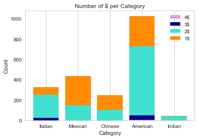

```python
from matplotlib import rc

# Establish our seaborn settings
sns.set()
# orgPalette = sns.color_palette("Set2", len(res_by_price))
# sns.set_palette(orgPalette)
sns.set_style("whitegrid", {'legend.frameon':False})

# set fig size
figsize= (100, 100, 50)

# Values for each stacked bar based on our above for loop
# This make the bar values dynamic so we do not have to manually set the values
bars1 = bars[0]
bars2 = bars[1]
bars3 = bars[2]
bars4 = bars[3]
x = np.arange(len(bars1))

# Plot our four bars from above values
four_dolla=plt.bar(x, bars4, color="plum")
three_dolla=plt.bar(x, bars3, color="darkblue", bottom=bars4)
two_dolla=plt.bar(x, bars2, color="turquoise", bottom=list(map(lambda x,y: x+y, bars3,bars4)))
one_dolla=plt.bar(x, bars1, color="darkorange", bottom=list(map(lambda x,y,z: x+y+z, bars3,bars4,bars2)))

# Set our xticks based on categories
plt.xticks(x, ["Italian","Mexican","Chinese","American", "Indian"])

# Set our grid
plt.grid(axis='y')

# Set graph labels
plt.xlabel("Category")
plt.ylabel('Count')
plt.title('Number of $ per Category')

# Set our legend
plt.legend((four_dolla[0], three_dolla[0],two_dolla[0], one_dolla[0]), ('4$', '3$','2$', '1$'), loc="best")


# Show graphic
plt.show()

# Save image
plt.savefig("stacked.png")
```

```python
# Established the regions we will loop through
region = ["NE","MW","WC","SW","SE"]

# Create and list of empty lists that will hold the count for $, $$, $$$, $$$$ per region
r_bars =[[],[],[],[]]

# Will first loop through the regions
for r in region:
    reg_bars= res_df.loc[res_df["Region"]==r, :]
    reg_counts = reg_bars["price"].value_counts()

    # Now will loop through the price ranges and if there is a price, it will append it to the matching empty list
    # If there is no restaurant in that price range, then the we will use the except and append a zero
    for price in range(1,5):
        try:
            r_bars[price-1].append(reg_counts[price])
        except:
            r_bars[price-1].append(0)

# Check
print(r_bars)
```

```
[[195, 184, 140, 43, 251], [367, 213, 250, 34, 333], [17, 10, 14, 0, 24], [0, 0, 0, 0, 6]]
```

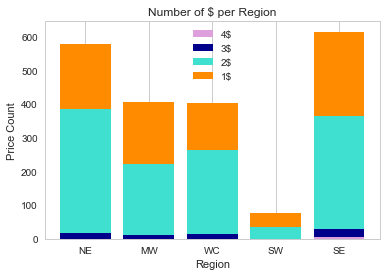

```python
# Establish our seaborn settings
sns.set()
# orgPalette = sns.color_palette("Set2", len(res_by_price))
# sns.set_palette(orgPalette)
sns.set_style("whitegrid", {'legend.frameon':False})

# set fig size
figsize= (100, 100, 50)

# Values for each stacked bar based on our above for loop
# This make the bar values dynamic so we do not have to manually set the values
bars1 = r_bars[0]
bars2 = r_bars[1]
bars3 = r_bars[2]
bars4 = r_bars[3]
x = np.arange(len(bars1))

# Plot our four bars from above values
four_dol = plt.bar(x, bars4, color="plum")
three_dol =plt.bar(x, bars3, color="darkblue", bottom=bars4)
two_dol =plt.bar(x, bars2, color="turquoise", bottom=list(map(lambda x,y: x+y, bars3,bars4)))
one_dol =plt.bar(x, bars1, color="darkorange", bottom=list(map(lambda x,y,z: x+y+z, bars3,bars4,bars2)))

# Set our xticks based on categories
plt.xticks(x, ["NE","MW","WC","SW","SE"])

# Set our grid
plt.grid(axis='y')

# Set graph labels
plt.xlabel("Region")
plt.ylabel('Price Count')
plt.title('Number of $ per Region')

# Set graph legend
plt.legend((four_dol[0], three_dol[0],two_dol[0], one_dol[0]), ('4$', '3$','2$', '1$'), loc="best")

# Show graphic
plt.show()

# Save image
plt.savefig("stacked2.png")
```

### Part 3: Pie Chart

```python
# Check our sums for pie chart
print(sum(bars1))
print(sum(bars2))
print(sum(bars3))
print(sum(bars4))
```

[output not shown]

```python
# Establish the auto percents
# Create definitions
def make_autopct(sizes):
    def my_autopct(pct):
        total = sum(sizes)
        val = int(round(pct*total/100.0))
        return '{p:.2f}%  ({v:d})'.format(p=pct,v=val)
    return my_autopct
```

```python
# Pie chart, where the slices will be ordered and plotted counter-clockwise:

# Establish our seaborn settings
sns.set()
orgPalette = sns.color_palette("Set2")
sns.set_palette(orgPalette)
# sns.set_style("", {'legend.frameon':False})

# set fig size
plt.figure(figsize=(20,20))

# Set our labels, sizes, and explode values
# We won't use labels because we will create a legend instead, but we could easily assign the labels

#labels = '4$', '3$','2$', '1$'
sizes = [sum(bars1),sum(bars2),sum(bars3),sum(bars4)]
explode = (0.03, 0.03, 0.03, 0.5)  # only "explode" the 2nd slice


# Plot our pie chart with total sums by $ breakdown and place the percetages
fig1, ax1 = plt.subplots()
ax1.pie(sizes, explode=explode, colors=orgPalette, autopct=make_autopct(sizes),
        shadow=True, startangle=90)

# Equal aspect ratio ensures that pie is drawn as a circle.
ax1.axis('equal')

# Set graph title
plt.title('Sum of each $ Amount')

# Set graph legend
plt.legend((four_dol[0], three_dol[0],two_dol[0], one_dol[0]), ('4$', '3$','2$', '1$'), loc="best")


# Show graphic
plt.show()

# Save image
plt.savefig("pie_chart.jpg")
```

[output not shown]

### Part 7: Limitations

Initially, we wanted to find out if there wass there a relationship between income and type of dining (ie dine-in, carry-out, delivery)? Is this based on the number of restaurants that provide these options?

Unfortunately, this didn’t work due to Yelp API limitations. Acoording to their website, currently, the transaction endpoint is "only supports food delivery in the US."

Since the current Yelp Fusion API only supports the delivery option it isn’t very helpful for comparison or analysis purposes.

### Part 8: If only we had more time...

- Attempt to match user category input with local restaurant
- "Build a lunch recommendation Slack bot that can pull highest rated Yelp places around your location. You can build the script to respond to user input (ex. “Chinese, $”) or generate top-rated places randomly." This was just too ambitious for our timeframe